# Lesson 8- Ordinations I

Liz Suter

6/24/2020

Load packages

```r
library(tidyverse)
library(phyloseq)
library(vegan)
library(ape)
```

Import the “cleaned up” R data object from lesson 4 of amplicons

```r
load("cleanedfiles.RData")
```

Import the metadata associated with the samples

```r
sample_info_tab<-read_tsv(url("https://raw.githubusercontent.com/biovcnet/amplicons-lesson-3-repo/master/qiime2_wd/sample_info.tsv"))
# Also delete the row with the QIIME2 category codes
sample_info_tab<- sample_info_tab[-c(1),]
```

The taxonomy in the taxonomy table is retained in one column and the different levels are separated by underscore, eg:

```r
head(taxonomy_no_contam)
```

```
## # A tibble: 6 x 3
##   `Feature ID`            Taxon                                       Confidence
##   <chr>                   <chr>                                            <dbl>
## 1 f0ef96bdea0473bc21cce9… D_0__Bacteria;D_1__Proteobacteria;D_2__Alp…      1.00
## 2 bf96a9ec42ba8692671457… D_0__Bacteria;D_1__Nitrospirae;D_2__Nitros…      0.740
## 3 342ba3312b63a3ad0e7738… D_0__Bacteria;D_1__Proteobacteria;D_2__Gam…      0.898
## 4 3db1f78506d300c6aab71a… D_0__Bacteria;D_1__Proteobacteria;D_2__Alp…      1.00
## 5 613748b1e7b2e205644183… D_0__Archaea;D_1__Thaumarchaeota;D_2__Nitr…      1.00
## 6 6ab5b3ceda3b4ca3bdef8d… D_0__Bacteria;D_1__Proteobacteria;D_2__Alp…      1.00
```

We want to move each taxonomic level to its own column by removing the ";D_#_" using regular expressions (see this [cheatsheet](https://evoldyn.gitlab.io/evomics-2018/ref-sheets/R_strings.pdf) about regexp)

```r
taxonomy <-  taxonomy_no_contam %>%
  mutate(taxonomy=str_replace_all(string=Taxon, pattern="D_\\d*\\__", replacement="")) %>%
  mutate(taxonomy=str_replace_all(string=taxonomy, pattern=";$", replacement="")) %>%
  separate(taxonomy, into=c("Kingdom", "Phylum", "Class", "Order", "Family", "Genus","Species"), sep=";") %>%
  select (-Taxon, -Confidence) %>%
  column_to_rownames(var = 'Feature ID')
head(taxonomy)
```

```
##                                   Kingdom         Phylum               Class
## f0ef96bdea0473bc21cce98767f548fa Bacteria Proteobacteria Alphaproteobacteria
## bf96a9ec42ba86926714575989bed1e8 Bacteria    Nitrospirae          Nitrospira
## 342ba3312b63a3ad0e77380db327abc0 Bacteria Proteobacteria Gammaproteobacteria
## 3db1f78506d300c6aab71a0fc0c73f89 Bacteria Proteobacteria Alphaproteobacteria
## 613748b1e7b2e2056441830f0a044c9d  Archaea Thaumarchaeota     Nitrososphaeria
## 6ab5b3ceda3b4ca3bdef8d2b26b7d593 Bacteria Proteobacteria Alphaproteobacteria
##                                             Order            Family
## f0ef96bdea0473bc21cce98767f548fa  Kordiimonadales        uncultured
## bf96a9ec42ba86926714575989bed1e8    Nitrospirales    Nitrospiraceae
## 342ba3312b63a3ad0e77380db327abc0            BD7-8              <NA>
## 3db1f78506d300c6aab71a0fc0c73f89  Kordiimonadales        uncultured
## 613748b1e7b2e2056441830f0a044c9d Nitrosopumilales Nitrosopumilaceae
## 6ab5b3ceda3b4ca3bdef8d2b26b7d593  Kordiimonadales        uncultured
##                                                                        Genus
## f0ef96bdea0473bc21cce98767f548fa bacterium endosymbiont of Osedax mucofloris
## bf96a9ec42ba86926714575989bed1e8                                  Nitrospira
## 342ba3312b63a3ad0e77380db327abc0                                        <NA>
## 3db1f78506d300c6aab71a0fc0c73f89 bacterium endosymbiont of Osedax mucofloris
## 613748b1e7b2e2056441830f0a044c9d                   Candidatus Nitrosopumilus
## 6ab5b3ceda3b4ca3bdef8d2b26b7d593 bacterium endosymbiont of Osedax mucofloris
##                                                                      Species
## f0ef96bdea0473bc21cce98767f548fa bacterium endosymbiont of Osedax mucofloris
## bf96a9ec42ba86926714575989bed1e8                    uncultured Cytophaga sp.
## 342ba3312b63a3ad0e77380db327abc0                                        <NA>
## 3db1f78506d300c6aab71a0fc0c73f89 bacterium endosymbiont of Osedax mucofloris
## 613748b1e7b2e2056441830f0a044c9d                                        <NA>
## 6ab5b3ceda3b4ca3bdef8d2b26b7d593 bacterium endosymbiont of Osedax mucofloris
```

Here we will do ordinations using the phyloseq package, which first requires making phyloseq objects out of each of our input data tables (in the last tutorial, I imported the tree using phyloseq so it is already a phyloseq object)

```r
ASV =   otu_table(data.frame(count_table_hellinger), taxa_are_rows =  TRUE)
TAX =   tax_table(as.matrix(taxonomy))
META    =   sample_data(data.frame(sample_info_tab, row.names = sample_info_tab$`sample-id`))
```

First check that the inputs are in compatible formats by checking for ASV names with the phyloseq function, taxa_names

```r
head(taxa_names(TAX))
```

```
## [1] "f0ef96bdea0473bc21cce98767f548fa" "bf96a9ec42ba86926714575989bed1e8"
## [3] "342ba3312b63a3ad0e77380db327abc0" "3db1f78506d300c6aab71a0fc0c73f89"
## [5] "613748b1e7b2e2056441830f0a044c9d" "6ab5b3ceda3b4ca3bdef8d2b26b7d593"
```

```r
head(taxa_names(ASV))
```

```
## [1] "f0ef96bdea0473bc21cce98767f548fa" "bf96a9ec42ba86926714575989bed1e8"
## [3] "342ba3312b63a3ad0e77380db327abc0" "3db1f78506d300c6aab71a0fc0c73f89"
## [5] "613748b1e7b2e2056441830f0a044c9d" "6ab5b3ceda3b4ca3bdef8d2b26b7d593"
```

```r
head(taxa_names(tree_no_contam))
```

```
## [1] "8fa673d962904defbef63397558b7577" "23d25af6e0a534e8e3fcc09609da60d4"
## [3] "e981001d8d4421f70827b78efb07115c" "c83985f2447be00d5f5d5628539120ad"
## [5] "d1c14546010f5062c408c4d0cd23aa6f" "d6ef69e92496a0135904f37165095a9f"
```

And check sample names were also detected

```r
head(sample_names(ASV))
```

```
## [1] "BW1"   "BW2"   "R10"   "R11"   "R11BF" "R12"
```

```r
head(sample_names(META))
```

```
## [1] "BW1"   "BW2"   "R10"   "R11BF" "R11"   "R12"
```

Make one phyloseq object, which contains all 4 objects:

```r
ps <- phyloseq(ASV, TAX,    META, tree_no_contam)
```

Check some features of the phyloseq object

```r
rank_names(ps)
```

```
## [1] "Kingdom" "Phylum"  "Class"   "Order"   "Family"  "Genus"   "Species"
```

```r
unique(tax_table(ps)[, "Kingdom"])
```

```
## Taxonomy Table:     [4 taxa by 1 taxonomic ranks]:
##                                  Kingdom
## 8fa673d962904defbef63397558b7577 "Eukaryota"
## d6ef69e92496a0135904f37165095a9f "Unassigned"
## 6043f853545ff10402026f05bcef3638 "Archaea"
## 6a0e58c2d956ad543c646382b9b1af79 "Bacteria"
```

```r
table(tax_table(ps)[, "Kingdom"], exclude = NULL)
```

```
##
##    Archaea   Bacteria  Eukaryota Unassigned
##        227       2959          6          2
```

Filter out those ambigious Kingdom annotations

```r
ps <- subset_taxa(ps, !is.na(Kingdom) & !Kingdom %in% c("Unassigned", "Eukaryota"))

table(tax_table(ps)[, "Kingdom"], exclude = NULL)
```

```
##
##  Archaea Bacteria
##      227     2959
```

Check out the phyla names

```r
table(tax_table(ps)[, "Phylum"], exclude = NULL)
```

```
##
##                 Acidobacteria                Actinobacteria
##                           195                           137
##                 Bacteroidetes                          BRC1
##                           118                            13
##               Calditrichaeota                    Chlamydiae
##                            23                             7
##                   Chloroflexi                 Cyanobacteria
##                           192                            17
##                  Dadabacteria           Deinococcus-Thermus
##                            43                             3
##                  Dependentiae             Entotheonellaeota
##                            14                             9
##            Epsilonbacteraeota                 Euryarchaeota
##                             1                            13
##                    Firmicutes              Gemmatimonadetes
##                            34                            92
##               Hydrogenedentes            Kiritimatiellaeota
##                             8                             5
##               Latescibacteria                 Lentisphaerae
##                            18                             1
##              Margulisbacteria Marinimicrobia (SAR406 clade)
##                             2                            14
##               Nanoarchaeaeota                   Nitrospinae
##                            18                            72
##                   Nitrospirae              Omnitrophicaeota
##                            54                             3
##               Patescibacteria                       PAUC34f
##                             8                             5
##                Planctomycetes                  Poribacteria
##                           253                             1
##                Proteobacteria                  Rokubacteria
##                          1526                            25
##              Schekmanbacteria                  Spirochaetes
##                            16                             2
##                Thaumarchaeota               Verrucomicrobia
##                           196                            35
##                  Zixibacteria                          <NA>
##                             1                            12
```

Filter out any with “NA” as phylum. There are also some very low abundance phyla here. I am going to filter these out, as they could influence the perceived differences in sample types. I am taking out any phyla with an abundance of 1 or 2:

```r
ps <- subset_taxa(ps, !is.na(Phylum) & !Phylum %in% c("", "Margulisbacteria", "Zixibacteria", "Epsilonbacteraeota", "Spirochaetes", "Lentisphaerae", "Poribacteria"))

table(tax_table(ps)[, "Phylum"], exclude = NULL)
```

```
##
##                 Acidobacteria                Actinobacteria
##                           195                           137
##                 Bacteroidetes                          BRC1
##                           118                            13
##               Calditrichaeota                    Chlamydiae
##                            23                             7
##                   Chloroflexi                 Cyanobacteria
##                           192                            17
##                  Dadabacteria           Deinococcus-Thermus
##                            43                             3
##                  Dependentiae             Entotheonellaeota
##                            14                             9
##                 Euryarchaeota                    Firmicutes
##                            13                            34
##              Gemmatimonadetes               Hydrogenedentes
##                            92                             8
##            Kiritimatiellaeota               Latescibacteria
##                             5                            18
## Marinimicrobia (SAR406 clade)               Nanoarchaeaeota
##                            14                            18
##                   Nitrospinae                   Nitrospirae
##                            72                            54
##              Omnitrophicaeota               Patescibacteria
##                             3                             8
##                       PAUC34f                Planctomycetes
##                             5                           253
##                Proteobacteria                  Rokubacteria
##                          1526                            25
##              Schekmanbacteria                Thaumarchaeota
##                            16                           196
##               Verrucomicrobia
##                            35
```

Re-root tree (from experience, I have had to do this because you may have removed the root of your tree when pruning). (I found this handy function from [here](https://john-quensen.com/r/unifrac-and-tree-roots/) which picks the longest branch to root from). There is also a compatibilty issue between the type of tree calculated by QIIME and the one expected by phyloseq, so we have to change that format as well (see [here](https://github.com/joey711/phyloseq/issues/936) for discussion)

```r
# first define function from link above to find furthest outgroup
pick_new_outgroup <- function(tree.unrooted){
require("magrittr")
require("data.table")
require("ape") # ape::Ntip
# tablify parts of tree that we need.
treeDT <-
     cbind(
         data.table(tree.unrooted$edge),
         data.table(length = tree.unrooted$edge.length)
     )[1:Ntip(tree.unrooted)] %>%
 cbind(data.table(id = tree.unrooted$tip.label))
 # Take the longest terminal branch as outgroup
 new.outgroup <- treeDT[which.max(length)]$id
 return(new.outgroup) }

# then run on my phyloseq tree
my.tree <- phy_tree(tree_no_contam)
out.group <- pick_new_outgroup(my.tree)
out.group
```

```
## [1] "8fa673d962904defbef63397558b7577"
```

```r
# Then use this outgroup to root the tree
new.tree1 <- ape::root(my.tree, outgroup=out.group, resolve.root=TRUE)


# and convert to dichotomy tree
new.tree2 <- ape::multi2di(new.tree1)
phy_tree(ps) <- new.tree2
phy_tree(ps)
```

```
##
## Phylogenetic tree with 3166 tips and 3165 internal nodes.
##
## Tip labels:
##  6043f853545ff10402026f05bcef3638, deb9d95a80e369e6252682e13bf86fda, be2d2edce95dfade46dc08e050afdacc, b9369b36c34d9c45dcd18b0c6b275643, 806013cf7a31572a0f49062d2bf3004e, 377c9295f3a4628dd39e1ad35af75a57, ...
## Node labels:
##  , 0.721, 0.973, 0.722, 0.000, 0.533, ...
##
## Rooted; includes branch lengths.
```

We can get more deeply into plotting in another lesson but for now let’s check overall how the phyla are distributed among samples. Phyloseq makes this easy

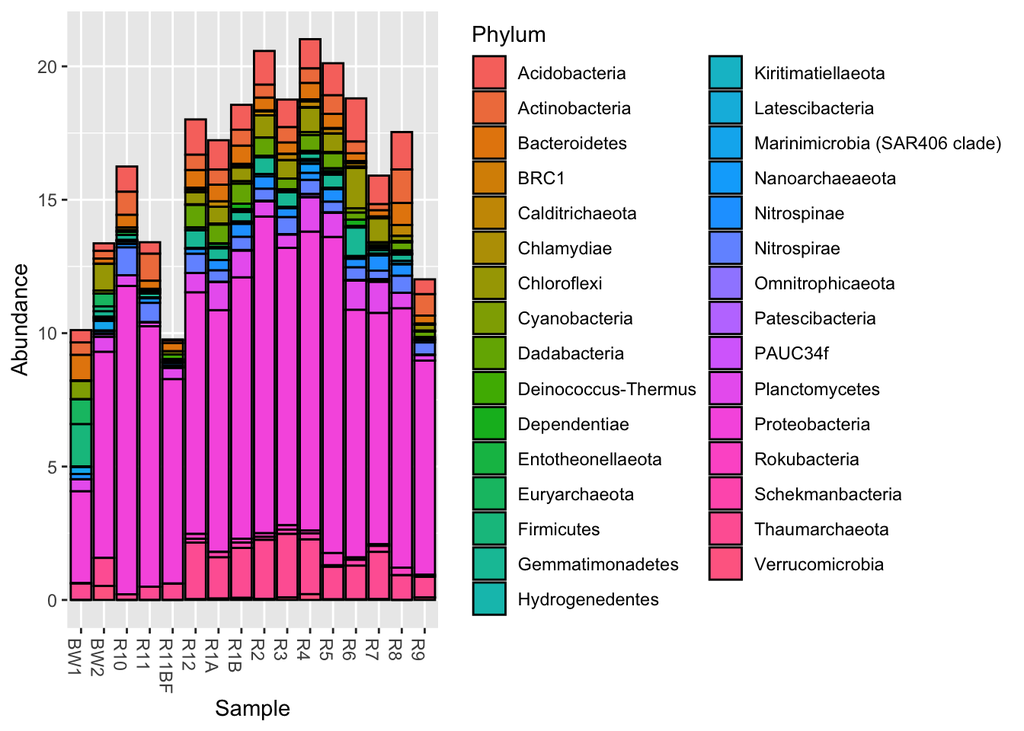

```r
# First aglomerate the ASVs at the phylum level using the phyloseq function, tax_glom
phylumGlommed = tax_glom(ps, "Phylum")
# and plot
plot_bar(phylumGlommed, x = "Sample", fill = "Phylum")
```

You can see there are a lot of Proteobacteria and also Thaumarchaeota, similar to Happy Belly. I didn’t do many prefiltering steps or re-arranging of the data table, so there is more to be done here. And remember, this OTU table is already tranformed, so it is really just a first glance. We can get more into appropriate plotting, etc. in another lesson.

**Finally we are ready to try some ordinations**

What is an ordination? *Ordination is a collective term for multivariate techniques which summarize a multidimensional dataset in such a way that when it is projected onto a low dimensional space, any intrinsic pattern the data may possess becomes apparent upon visual inspection* (Pielou, 1984).

The first one to try here will be a **principal coordinate analysis (PCoA)**, PCoA tries to represent the distance between objects by projecting their dissimilarity into a 2- or 3-D (Euclidean) space. We will using the “bray” method (Bray-Curtis) to calculate the dissimilarity matrix. You can build the dissimilarity method directly into the PCoA calculation, but first let’s do it on it’s own to check what the matrix looks like:

```r
ps_dist <- distance(ps, method = "bray")
ps_dist
```

```
##             BW1       BW2       R10       R11     R11BF       R12       R1A
## BW2   0.9236381
## R10   1.0000000 0.9966805
## R11   1.0000000 1.0000000 0.6892528
## R11BF 1.0000000 1.0000000 0.9744624 0.9524113
## R12   1.0000000 0.9943282 0.8601140 0.8785128 0.9848011
## R1A   0.9986627 0.9981382 0.8659543 0.9001354 0.9900611 0.6981735
## R1B   0.9988777 0.9982156 0.8556017 0.9068073 0.9853341 0.6757195 0.5394394
## R2    1.0000000 0.9991078 0.8139254 0.8669915 0.9815828 0.7511611 0.7224756
## R3    0.9792128 1.0000000 0.8579751 0.8946156 0.9917593 0.8496322 0.8244764
## R4    0.9942210 0.9977240 0.8835262 0.9183572 1.0000000 0.8152938 0.7753644
## R5    0.9972229 1.0000000 0.8127689 0.8613745 0.9866644 0.7447184 0.7378634
## R6    1.0000000 0.9982290 0.9285682 0.9401695 0.9970775 0.7054925 0.7304405
## R7    0.9802440 1.0000000 0.9520203 0.9570374 0.9921306 0.8607544 0.8972757
## R8    0.9985409 1.0000000 0.7568934 0.7702897 0.9811377 0.8983852 0.8775990
## R9    0.9943727 1.0000000 0.7698509 0.8271673 0.9752830 0.8692261 0.8580463
##             R1B        R2        R3        R4        R5        R6        R7
## BW2
## R10
## R11
## R11BF
## R12
## R1A
## R1B
## R2    0.6774096
## R3    0.7925706 0.7423478
## R4    0.7051804 0.6685017 0.7107583
## R5    0.7082431 0.6539689 0.6956333 0.7123409
## R6    0.7303693 0.7473211 0.8461916 0.8260364 0.7655158
## R7    0.8803448 0.8955036 0.9088350 0.8942263 0.8869853 0.9096940
## R8    0.8866150 0.8517977 0.8250369 0.8789975 0.8412761 0.9358342 0.9635411
## R9    0.8700149 0.8111809 0.8307965 0.8065757 0.8245767 0.9103893 0.9470649
##              R8
## BW2
## R10
## R11
## R11BF
## R12
## R1A
## R1B
## R2
## R3
## R4
## R5
## R6
## R7
## R8
## R9    0.8391216
```

Next plot the PCoA

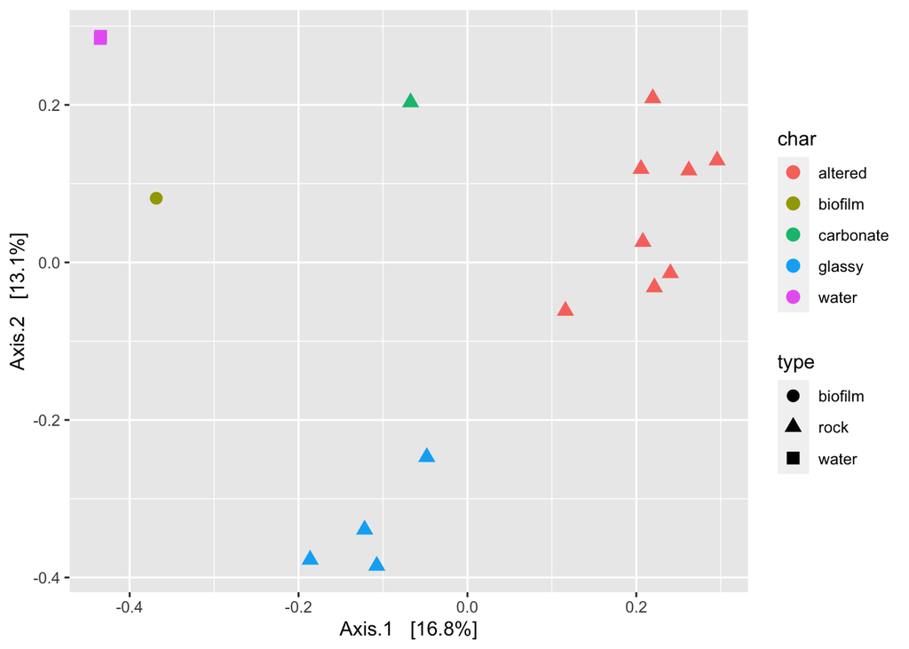

```r
out.pcoa <- ordinate(ps, method = "PCoA", distance = "bray")
pcoa_plot = plot_ordination(ps, out.pcoa, color ="char", shape = "type") +
  geom_point(size = 3)
pcoa_plot
```

Each PCoA is associated with eigenvectors and eigenvalues. This is my simplified ecologists understanding of this: Each data matrix (like a dissimilarity matrix) has many, many dimensions, which cannot be well represented in a 2D or 3D coordinate system. But we can rotate the coordinates of this data projection into a new coordinate system, without changing the positions of the points relative to each other. The PCoA calculation attempts to rotate the new coordinates in a way such that much of the varibility can be represented by as few axes as possible. In the new coordinate system, each axis, or eigenvector, is associated with its own eigenvalue. The eigenvalue is a scalar value that represents how much varibility can be explained by that axis.

Phyloseq already told us that the two first axes above explain 29.9% (13.1+16.8) of the variability in the entire dataset. The first two axes are plotted with equal lengths but this is not a fair way of representing this, as the first axes has a larger Eigenvalue. There you can scale the axes according to the size of the eigenvalues (I got this idea from [Bioconductor](https://bioconductor.org/help/course-materials/2017/BioC2017/Day1/Workshops/Microbiome/MicrobiomeWorkflowII.html))

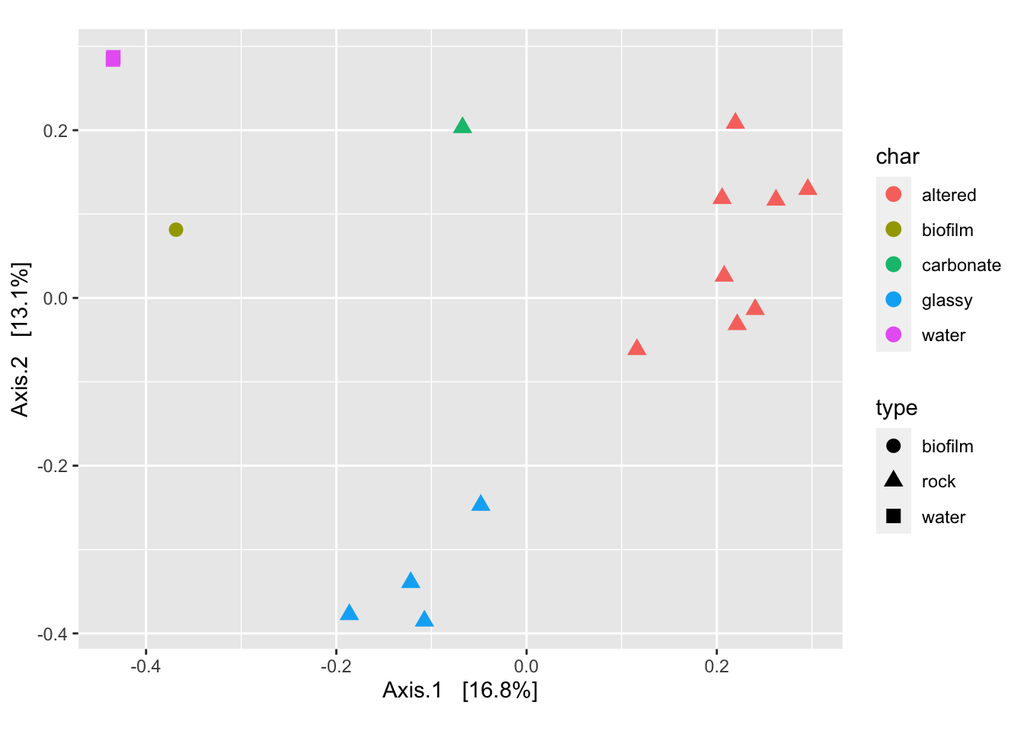

```r
evals <- out.pcoa$values$Eigenvalues
pcoa_plot.scaled = plot_ordination(ps, out.pcoa, color ="char", shape = "type") +
  geom_point(size = 3) +
  coord_fixed(sqrt(evals[2] / evals[1]))
pcoa_plot.scaled
```

Next, I will demonstrate a **weighted UniFrac PCoA**. When calculating the distance matrix, this takes into account how many related taxa are shared among each pair of samples using the phylogenetic tree (which we embedded in the phyloseq object). It then performs the PCoA:

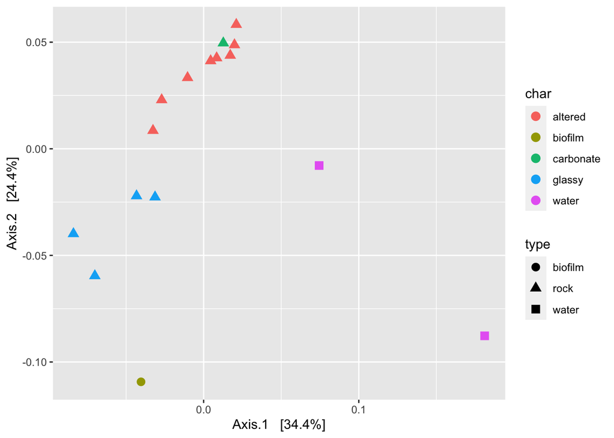

```r
out.pcoa <- ordinate(ps, method = "PCoA", distance = "wunifrac")
wuf_pcoa_plot = plot_ordination(ps, out.pcoa, color ="char", shape = "type") +
  geom_point(size = 3)
wuf_pcoa_plot
```

Third, I will demonstrate a **non-metric dimensional scaling (NMDS) ordination**. (Note, PCoA is also known as classical metric dimensional scale, MDS). NMDS also attempts to represent distances in a low-dimensional space, but in this case the distances are replaced with ranks, and therefore we won’t have an idea of the magnitude of the differences. It also iteratively places the data object on the axes (rather than rotating the axes and keeping the data objects the same) until it finds the best solution. Therefore it will find a unique solution each time you run it. Because of this, we also cannot say anything about the amount of variance explained by the axes. Instead, we report the stress of the analysis, which is like the “disagreement” between the 2D representation and the actual ranked distances. If this stress is more than 0.2, you don’t want to use this analysis:

```r
out.nmds <- ordinate(ps, method = "NMDS", distance = "bray")
```

```
## *** Solution reached
```

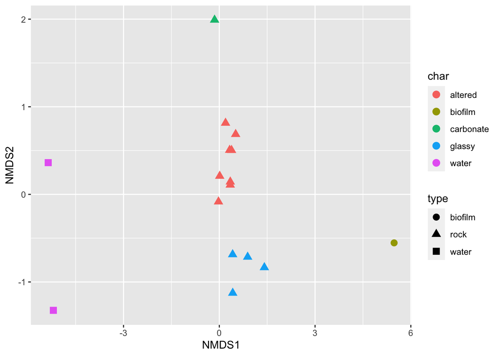

```r
nmds_plot = plot_ordination(ps, out.nmds, color ="char", shape = "type") +
  geom_point(size = 3)
nmds_plot
```